# Missing data in R

Guido Biele

April 2019

The goal of this session is to briefly introduce dealing with missing data in R. We do this by first getting an overview about types of missing data, then moving on to general ways to deal with missing data, and finally looking at a few examples to do analyses in R when data is missing.

Before we get a quick overview about types of missing data, lets clarify why we should worry about it. The reasons are:

- missing data can lead to biased effect sizes, i.e. a complete-case analysis can result in estimates that over or underestimate the true effect sizes in the population.
- missing data can lead to inflated variance, i.e. standard errors (and following p-values or posterior variances) from a complete-cases analysis are larger than they need to be.

## Representation of missing data in R

For those who have not worked much with R yet:

Missing data are represent by `NA`.

```r
id = c(1, 2, 3, 4, NA, 5, 6, NA, 8, 9)
id
```

```
##  [1]  1  2  3  4 NA  5  6 NA  8  9
```

One can use the `is.na` function to find missing data.

```r
is.na(id)
```

```
##  [1] FALSE FALSE FALSE FALSE  TRUE FALSE FALSE  TRUE FALSE FALSE
```

If one uses a function on an object with missing data, R returns `NA`.

```r
max(id)
```

```
## [1] NA
```

To avoid this, we have to specify that missing data are removed before the operation is performed.

```r
max(id, na.rm = T)
```

```
## [1] 9
```

We also need to work around `NA` when doing logical indexing.

```r
dta =data.frame(E = rnorm(10),
                O = rnorm(10))
dta[id > 5,]
```

```
##               E         O
## NA           NA        NA
## 7    -0.9953809  1.036415
## NA.1         NA        NA
## 9     0.2586920 -2.139036
## 10    1.4825066 -0.162428
```

```r
dta[which(id > 5),]
```

```
##             E         O
## 7  -0.9953809  1.036415
## 9   0.2586920 -2.139036
## 10  1.4825066 -0.162428
```

Regression analysis will by default be performed on the complete cases:

```r
dta[is.na(id),] = NA
lm_fit = lm(E ~ O, dta)
summary(lm_fit)
```

```
##
## Call:
## lm(formula = E ~ O, data = dta)
##
## Residuals:
##      Min       1Q   Median       3Q      Max
## -1.51500 -0.38181 -0.09538  0.34317  1.69133
##
## Coefficients:
##             Estimate Std. Error t value Pr(>|t|)
## (Intercept)  -0.2721     0.3671  -0.741    0.487
## O            -0.3894     0.3694  -1.054    0.332
##
## Residual standard error: 1.015 on 6 degrees of freedom
##   (2 observations deleted due to missingness)
## Multiple R-squared:  0.1563, Adjusted R-squared:  0.01565
## F-statistic: 1.111 on 1 and 6 DF,  p-value: 0.3324
```

## Types of missing data

Rubin (1976) originally proposed a classification of missing data into three types:

- **MCAR** or Missing Completely At Random (here, “nomen est omen”)
- **MAR** or Missing At Random (i.e., missing is random conditional on additional observed variables)
- **MNAR** or Missing Not At Random (is not MCAR or MAR)

One way to better understand these different types of missingness is to use directed acyclic graphs (DAGs) and draw missingness or m-graphs (e.g. Mohan & Pearl, 2018). To explain m-graphs, lets start with a simple example (modified from Mohan & Pearl 2018, who were inspired by Little & Rubin, 2002): We want to investigate the effects of education and age on obesity. A simple DAG that represents this relationship looks as follows:

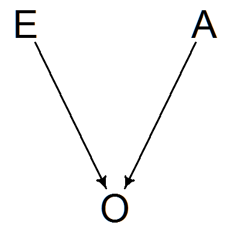

```r
library(dagitty)

simple_dag = dagitty("
A 1 @1,0
O O @0,1
E E @-1,0

A O
E O
")
drawdag(simple_dag)
```

This DAG represents the assumption that education (E) and age (A) are causes of obesity (O).

To represent missingness, m-graphs introduce a new variable `O*` for observable O’s. `O*` depends on O and R<sub>O</sub>, the latter of which indexes if O is observable. At the same time, the original variable O becomes a unobserved (latent) variable. Here is such a graph:

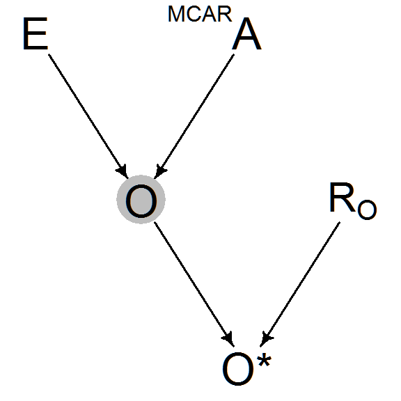

```r
mcar_dag = dagitty("
A  1 @1,0
O  U @0,1
E  E @-1,0
O* O @1,2
R_O 1 @2,1

A O
E O
O O*
R_O O*
")
drawdag(mcar_dag)
mtext("MCAR",side = 3,line = -1)
```

This DAG represents a situation with where missingness is completely at random (MCAR) because no arrwo goes into R~O.

The following DAG describes missingness at random (MAR):

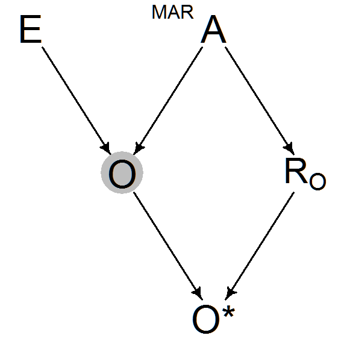

```r
mar_dag = dagitty("
A  1 @1,0
O  U @0,1
E  A @-1,0
O* O @1,2
R_O 1 @2,1

A O R_O
E O
O O*
R_O O*
")
drawdag(mar_dag)
mtext("MAR",side = 3,line = -1)
```

Here, missingness is random, given that we know age

Finally, we can look at a situation where missingness is not at random, even taking into account age:

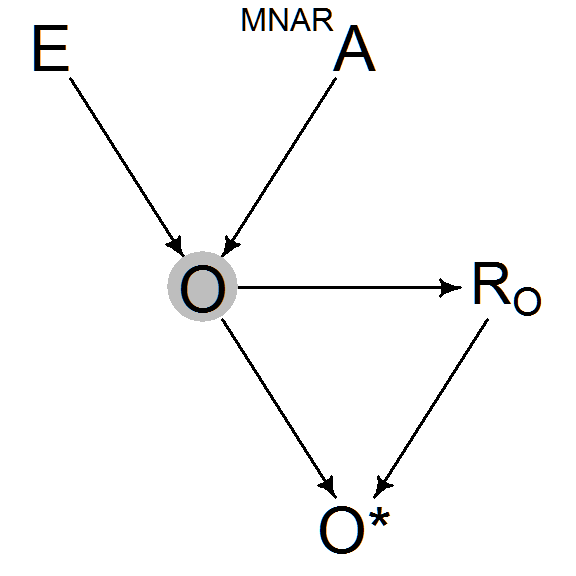

```r
mnar_dag = dagitty("
A  1 @1,0
O  U @0,1
E  E @-1,0
O* O @1,2
R_O 1 @2,1

A O
O R_O
E O
O O*
R_O O*
")
drawdag(mnar_dag)
mtext("MNAR",side = 3,line = -1)
```

Note that for the observer missing is not at radnom, because O is a latent variable.

Let’s compare these three DAGs:

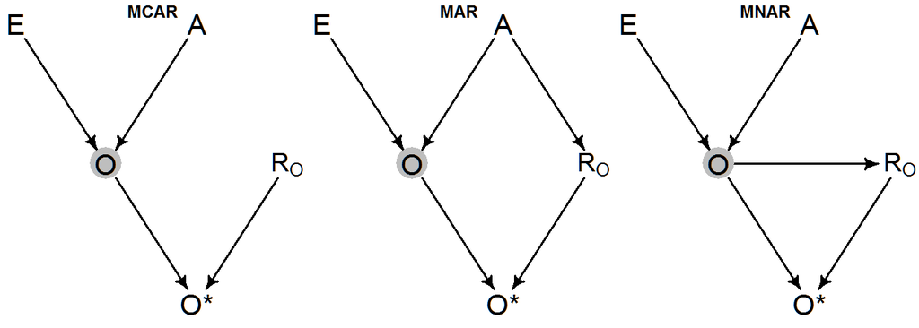

```r
par(mfrow = c(1,3))
drawdag(mcar_dag)
title("MCAR",line = -1)
drawdag(mar_dag)
title("MAR",line = -1)
drawdag(mnar_dag)
title("MNAR",line = -1)
```

A distinction of these types of missingness is important, because they determine if we can still estimate “unbiased” effects and how we need to handle missing data in order to obtain unbiased effects.

### If the outcome variable is MNAR, it is not possible to obtain unbiased association/effect estimates

In particular, if data are *MNAR*, there is little we can do [^1]. To illustrate the problem lets simulate data for the MNAR situation:

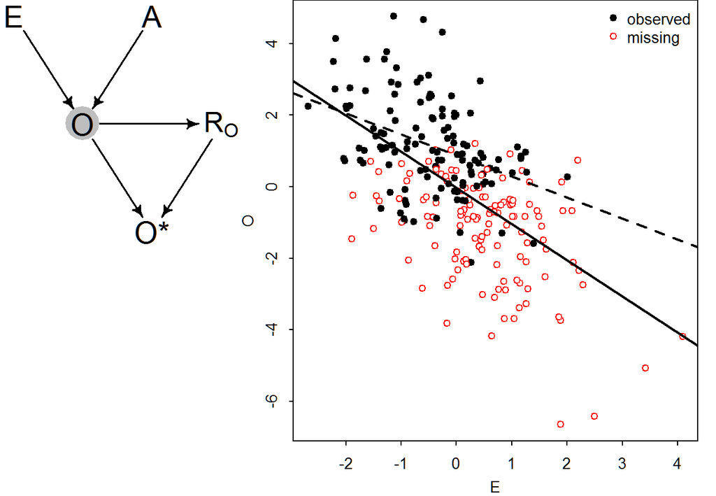

```r
library(boot)

N = 250
E = rnorm(N)
A = rnorm(N)
O = A - E + rnorm(N)
R_O = (O+rnorm(N)) > 0

layout(matrix(c(1,0,2,2),nrow = 2),widths = c(1/3,2/3))
drawdag(mnar_dag)

par (mar=c(3,3,0,1), mgp=c(2,.7,0), tck=-.01)
plot(E,O, pch = 21, bg= R_O, col = (!R_O)+1)
abline(lm(O~E), col = "black", lwd = 2)
abline(lm(O[R_O]~E[R_O]), lwd = 2, lty = 2)
legend("topright",
       pch = c(21,21),
       col = c("black","red"),
       pt.bg = c(1,0),
       legend = c("observed","missing"),
       bty = "n")
```

In this example, we used vectors of data with complete cases as input, which does not show how R automatically deals with missing data.

### When the data is *MCAR*, simple list-wise deletion (complete case analysis) still provides consistent effect size estimates

Note though that while list-wise deletion gives us an unbiased effect size, we still get inflated standard errors. The following code also shows implicitly that R’s default way of dealing with missing data is list-wise/complete case analysis.

```r
my_data = sim_mDAG(mcar_dag, N = N)
head(my_data)
```

```
##         O*            A            E          O   R_O
## 1       NA  0.001187276  0.110510401  0.1853167 FALSE
## 2       NA  0.005581660 -0.414254000 -0.8139798 FALSE
## 3       NA  0.588365142 -1.084992082  1.3462156 FALSE
## 4       NA -0.374986031 -0.359015758 -1.6567387 FALSE
## 5       NA -1.494545850 -0.092210216 -0.6360713 FALSE
## 6 1.112958 -2.255498974 -0.001288582  1.1129577  TRUE
```

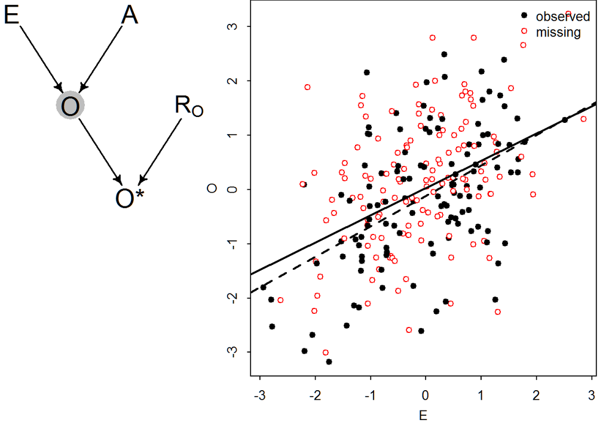

```r
lm_population = lm(O ~ E,my_data)
lm_observed = lm(`O*` ~ E,my_data)

layout(matrix(c(1,0,2,2),nrow = 2),widths = c(1/3,2/3))
drawdag(mcar_dag)

par (mar=c(3,3,0,1), mgp=c(2,.7,0), tck=-.01)
plot(my_data$E,
     my_data$O,
     pch = 21,
     bg = my_data$R_O,
     col = (!my_data$R_O)+1,
     xlab = "E", ylab = "O")
abline(lm_population, col = "black", lwd = 2)
abline(lm_observed, lwd = 2, lty = 2)
legend("topright",
       pch = c(21,21),
       col = c("black","red"),
       pt.bg = c(1,0),
       legend = c("observed","missing"),
       bty = "n")
```

```r
summary(lm_population)
```

```
##
## Call:
## lm(formula = O ~ E, data = my_data)
##
## Residuals:
##     Min      1Q  Median      3Q     Max
## -2.9424 -0.6851 -0.0699  0.7531  2.9221
##
## Coefficients:
##             Estimate Std. Error t value Pr(>|t|)
## (Intercept)  0.03365    0.06964   0.483    0.629
## E            0.50211    0.06478   7.752 2.34e-13 ***
## ---
## Signif. codes:  0 '***' 0.001 '**' 0.01 '*' 0.05 '.' 0.1 ' ' 1
##
## Residual standard error: 1.097 on 248 degrees of freedom
## Multiple R-squared:  0.195,  Adjusted R-squared:  0.1918
## F-statistic: 60.09 on 1 and 248 DF,  p-value: 2.339e-13
```

```r
summary(lm_observed)
```

```
##
## Call:
## lm(formula = `O*` ~ E, data = my_data)
##
## Residuals:
##      Min       1Q   Median       3Q      Max
## -2.61918 -0.67159 -0.06917  0.72445  2.86636
##
## Coefficients:
##             Estimate Std. Error t value Pr(>|t|)
## (Intercept) -0.11496    0.10021  -1.147    0.254
## E            0.56140    0.09102   6.168 1.04e-08 ***
## ---
## Signif. codes:  0 '***' 0.001 '**' 0.01 '*' 0.05 '.' 0.1 ' ' 1
##
## Residual standard error: 1.087 on 116 degrees of freedom
##   (132 observations deleted due to missingness)
## Multiple R-squared:  0.247,  Adjusted R-squared:  0.2405
## F-statistic: 38.04 on 1 and 116 DF,  p-value: 1.04e-08
```

The degrees of freedom in the outputs above show us the difference in number of cases included in the analysis. The next figure shows regression coefficients and confidence intervals for both analysis. [Also, **I wish somebody could remove the ridiculous significance codes!**]

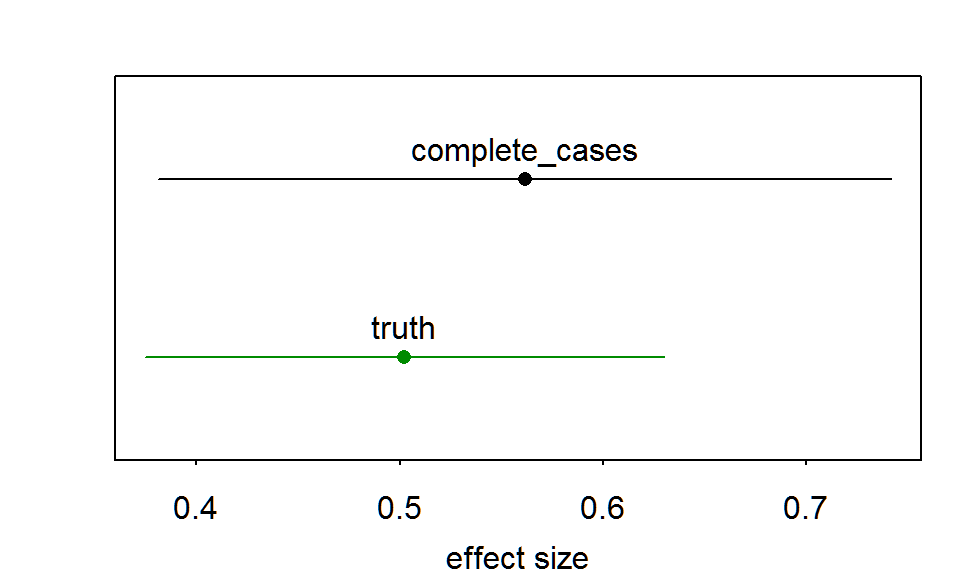

```r
es = rbind(truth =          get_esci(lm_population)[2,],
           complete_cases = get_esci(lm_observed)[2,])
plot_coefs(es)
```

## Testing assumptions about missingness

The DAGs shown above are important, because they make it (relatively) easy to detect what type of missingness is present in the data. This is relevant because all methods used to deal with missing data build on some assumptions. If these assumptions are violated, our analysis will still produce invalid results, even if it (tries to) somehow account for missingness with methods like FIML or multiple imputation (MI, described below). Therefor, one should always check if the assumption of MAR holds.

### MCAR vs MAR

One point of DAGs that is easily overlooked is that missing paths are as informative as present paths. In particular, if there is no path between two variables in a DAG or one blocks the path by adjusting for a variable on the path, then the variables should be independent according to the DAG. The term for this is implied (conditional) indenpence. And one straight-forward way to examine if the DAG one hypothesizes is consistent with the data is to examine if the implied conditional indendencies of the DAG are present in the data.

We can use the function `impliedConditionalIndependencies` from the [dagitty package](https://cran.r-project.org/web/packages/dagitty/) to see those for the MCAR and MAR cases above (We don’t need `dagitty` in this case, but it is useful for more complex DAGs.):

```r
impliedConditionalIndependencies(mcar_dag)
```

```
## A _||_ E
## A _||_ R_O
## E _||_ R_O
```

```r
impliedConditionalIndependencies(mar_dag)
```

```
## A _||_ E
## E _||_ R_O
```

Unsurprisingly, the MCAR assumption implies more independencies. In particular, only the MCAR model assumes that participation (R<sub>O</sub>) is independent of age (A). If we want to test this assumption for our data, we can simply run a regression model `lm(R_o ~ A)` and expect that the coefficient for A is zero. The next few lines of code simulate data from the MCAR and MAR models, each time assuming that the effect size for each path is 0.5, and check the implied conditional independence “A _||_ R_O” that holds only for the MCAR model.

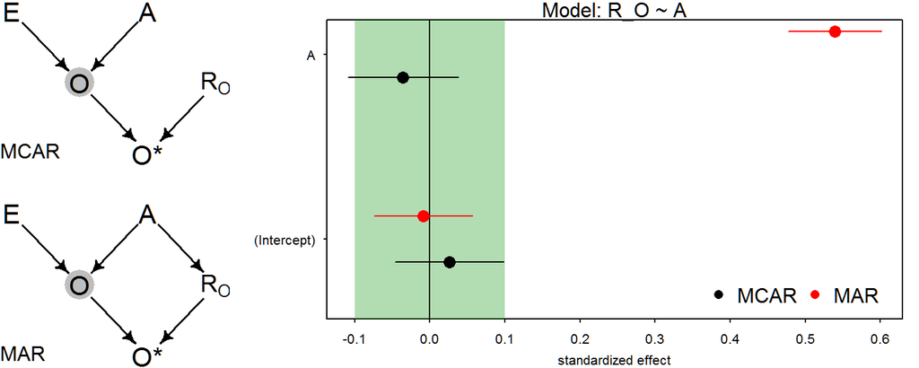

```r
layout(matrix(c(1,0,2,3,3,3),ncol = 2),
       widths = c(.25,.75),
       heights = c(.45,.1,.45))

data_mar = simulateSEM(mar_dag,
                       b.default = .5)
data_mcar = simulateSEM(mcar_dag,
                        b.default = .5)

fit_mar = lm(R_O ~ A, data_mar)
fit_mcar = lm(R_O ~ A, data_mcar)


drawdag(mcar_dag)
mtext("MCAR",side = 1, line = -1.25,adj = 0)
drawdag(mar_dag)
mtext("MAR", side = 1, line = -1.25,adj = 0)
coefplot2(fit_mcar,
          fit_mar,
          ttl = "R_O ~ A")
```

We see that the regression coefficient for A is not in a region of practical equivalence of +/- .1. Therefor, the assumptions of independence of A and R_O does not hold for the data from the MAR DAG and we cannot simply do a complete case analysis for this data.

### Assessing *equivalence* is required to evaluate conditional indendence

The use of a region of practical equivalence is rooted in the procedure for [equivalence tests](https://en.wikipedia.org/wiki/Equivalence_test). If we want to show that a regression coefficient is (close to) zero, it is not sufficient to show that it is not significance. Rather, one has to show that the regression coefficient is with high certainty very small. How small “very small” is should generally be determined by subject matter experts. One possible rule of thumb is that an effect that is only 1/10 of a practically meaningful effect has practically equivalent with zero. Another rule of thumb could be that such a very small effect should be smaller than the expected effect size of your exposure outcome association [^2]. In the application above, I chose an effect size of smaller than 0.1 SMD to be practically equivalent with 0. Tests for equivalence work by checking if the 90% CIs lie within the ROPE. If you need p-values for this, you can use the [equivalence](https://cran.r-project.org/web/packages/equivalence/) package.

### MAR vs MNAR

We can also check if the assumption of MAR holds. First, lets look at two new examples of a MAR and MNAR situation:

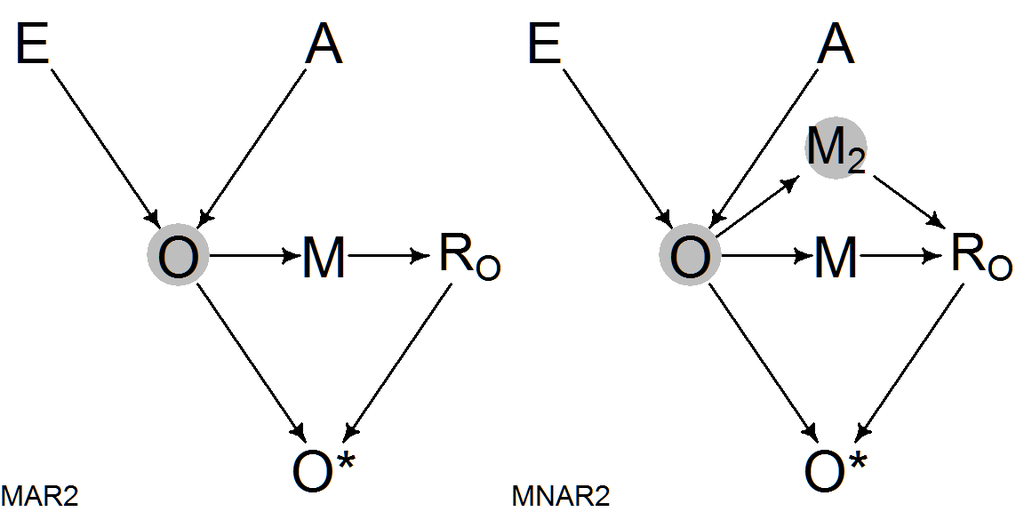

```r
mnar2_dag = dagitty("
A 1 @1,0
O U @0,1
E E @-1,0
O* O @1,2
R_O 1 @2,1
M 1 @1,1
M_2 U @1,.5

A O
O M
M R_O
E O
O O*
R_O O*
O M_2
M_2 R_O
")
mnar2_dag = gsub("O -> M_2","O -> M_2 [beta = 1]", mnar2_dag)


mar2_dag = dagitty("
A  1 @1,0
O  U @0,1
E  E @-1,0
O* O @1,2
R_O 1 @2,1
M 1 @1,1

A O
O M
M R_O
E O
O O*
R_O O*
")

par(mfrow = c(1,2))
drawdag(mar2_dag)
mtext("MAR2",1,line = -1,adj = 0)
drawdag(mnar2_dag)
mtext("MNAR2",1,line = -1,adj = 0)
```

```r
impliedConditionalIndependencies(mar2_dag)
```

```
## A _||_ E
## A _||_ R_O | M
## E _||_ R_O | M
```

```r
impliedConditionalIndependencies(mnar2_dag)
```

```
## A _||_ E
```

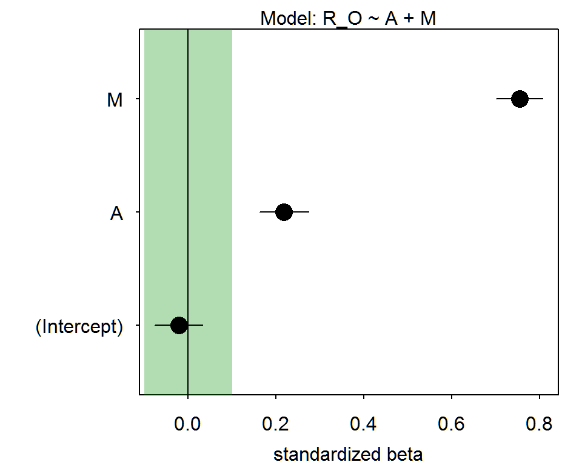

```r
data_mnar2 = simulateSEM(mnar2_dag,b.default = .5)
lmfit = lm(formula = R_O ~ A + M, data = data_mnar2)
cis = confint(lmfit)
par (mar=c(3,6,1.25,1), mgp=c(2,.7,0), tck=-.01)
plot(0, type = "n",
     ylim = c(.5,3.5),
     xlim = range(cis),
     yaxt = "n", ylab = "",
     xlab = "standardized beta")
axis(2,at = 1:3, labels = rownames(cis), las = 2)
rect(xleft = -.1,ybottom = 0,xright = .1,ytop = 5,
     col = adjustcolor("green4",alpha = .3), border = NA)
abline(v = 0)
segments(x0 = cis[,1],x1 = cis[,2],y0 = 1:3)
points(coef(lmfit),1:3, pch = 16, cex = 2)
mtext("Model: R_O ~ A + M")
```

```r
summary(lmfit)
```

```
##
## Call:
## lm(formula = R_O ~ A + M, data = data_mnar2)
##
## Residuals:
##     Min      1Q  Median      3Q     Max
## -1.8917 -0.4109 -0.0171  0.4392  2.1317
##
## Coefficients:
##             Estimate Std. Error t value Pr(>|t|)
## (Intercept) -0.02173    0.02745  -0.791    0.429
## A            0.21827    0.02852   7.654 1.02e-13 ***
## M            0.75407    0.02735  27.572  < 2e-16 ***
## ---
## Signif. codes:  0 '***' 0.001 '**' 0.01 '*' 0.05 '.' 0.1 ' ' 1
##
## Residual standard error: 0.6126 on 497 degrees of freedom
## Multiple R-squared:  0.6559, Adjusted R-squared:  0.6545
## F-statistic: 473.6 on 2 and 497 DF,  p-value: < 2.2e-16
```

## Missingness dependent on a predictor variables is a minor problem

When dealing with missing data, it makes a big difference if missingness is associated with the outcome or predictor variables. If there is only one predictor and missingness depends on the predictor variable list-wise deletion is not so problematic ([more here](http://statisticalhorizons.com/listwise-deletion-its-not-evil)). Here is an example DAG:

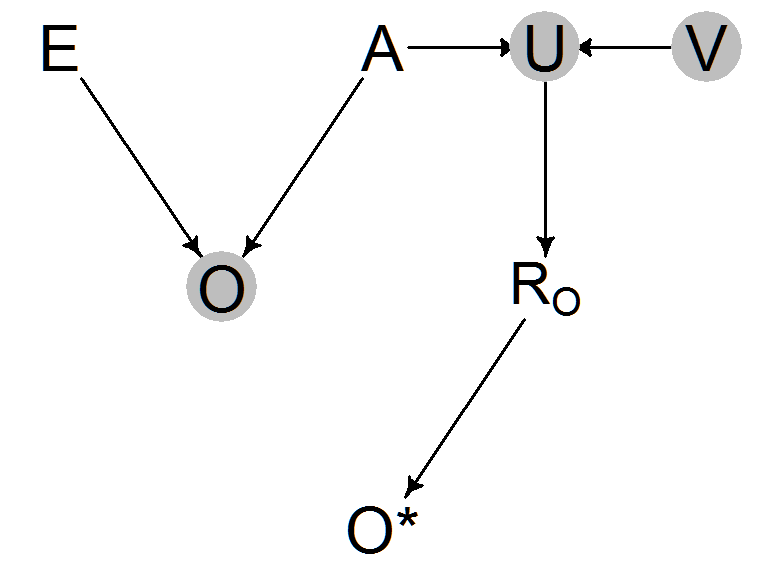

```r
mnarpred_dag = dagitty("
A  1 @1,0
O  U @0,1
E  E @-1,0
O* O @1,2
R_O 1 @2,1
U U @2,0
V U @3,0

A O [beta = 1]
E O
R_O O*
A U
U R_O
V U
")

mnarpred_dag = gsub("E -> U","E -> U [beta = 1]", mnarpred_dag)
mnarpred_dag = gsub("U -> R_O","U -> R_O [beta = 1]", mnarpred_dag)
drawdag(mnarpred_dag)
```

And here the results of an analysis of the full data set and the complete cases:

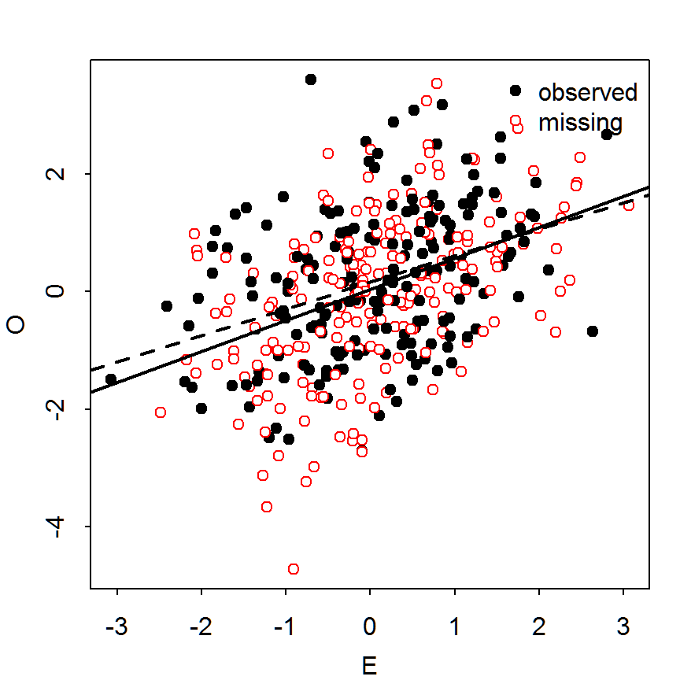

```r
mnarpred_data = sim_mDAG(mnarpred_dag, N = 400)
tmp = list2env(as.list(mnarpred_data),envir = .GlobalEnv)

par (mar=c(3,3,2,1), mgp=c(2,.7,0), tck=-.01)
plot(E,O, pch = 21, bg= R_O, col = (!R_O)+1)
abline(lm(O~E), col = "black", lwd = 2)
abline(lm(`O*`[R_O]~E[R_O]), col = "black", lwd = 2, lty = 2)
legend("topright",
       pch = c(21,21),
       col = c("black","red"),
       pt.bg = c(1,0),
       legend = c("observed","missing"),
       bty = "n")
```

In the case of only one exposure that also determines missingness, one could hence simply analyse the complete cases [^3]. However, if there a multiple predictors in a model, it can quickly become impractical to delete every case with a missing value in one of the predictor variables.

To summarize this general section about missing data:

- MCAR, MAR, and MNAR are three different types of missingness, each with different consequences for the data analysis
- missingness dependent on the outcome variable is generally much more problematic than missingness dependent on a predictor variable.
- A good workflow for statistical analysis includes making assumptions about missing data explicit. Missingness graphs using DAGs are useful for this. (one might find out that complete case analysis is OK [^4] )
- It is good practice to check if the data at hand are consistent with the assumptions made (though, as some might nitpick, a verified assumption is no longer an assumptions).

## Methods to deal with (at least) MAR data

### Don’t use ad hoc “methods”

Before introducing methods to deal with missing data, let’s mention what is not really OK: Imputation of missing data with the mean or median of the non-missing data might be convenient, but does not work. The next figure illustrates why:

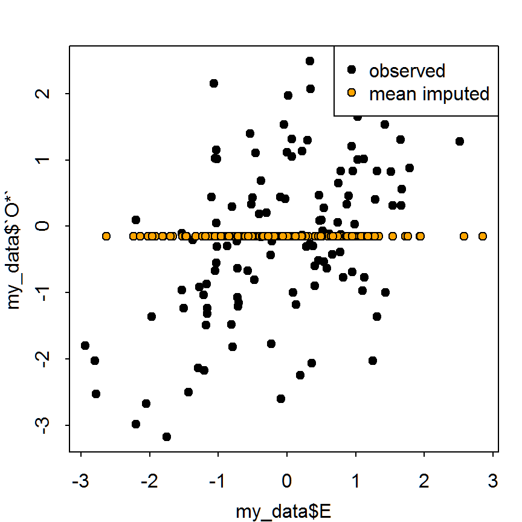

```r
my_data$O_mean_imputation = my_data$`O*`
my_data$O_mean_imputation[is.na(my_data$`O*`)] =
  mean(my_data$O_mean_imputation[!is.na(my_data$`O*`)])

par (mar=c(3,3,2,1), mgp=c(2,.7,0), tck=-.01)
plot(my_data$E,
     my_data$`O*`,
     pch = 21, bg = "black")
points(my_data$E[!my_data$R_O],
       my_data$O_mean_imputation[!my_data$R_O],
       pch = 21,
       bg = "orange")
legend("topright",
       pch = 21,
       pt.bg = c("black","orange"),
       legend = c("observed","mean imputed"))
```

One might think that it is the best to just use list-wise deletion (complete case analysis) when the data is MCAR. Indeed, this would not introduce bias. But, as we have seen earlier, throwing away data increases the standard error of parameter estimates. Therefore, it can be useful to not simply do a complete case analysis when data is MCAR.

Some authors give the name *ad hoc techniques* to methods that somehow deal with missing data, but do not come with a theory or explanation of why they should work. List-wise deletion, pairwise deletion, mean/median/mode imputation, and complete case analysis belong into this group. We will not look further into these methods.

### Real methods

*All statistical methods to “really” deal with missing data assume that missingness is MAR.* I am aware of following ways to substantially deal with missing data:

- Adjustment for predictors of missingness.
- Full information maximum likelihood (FIML). In short, this approach models the joint likelihood of all available data (typically using a multivariate normal distribution) plus parameters of interest like path (or regression) coefficients.
- Multiple imputation (MI). In MI, the analyst uses methods like Multiple Imputation by Chained Equations (MICE) or Hot Deck to generate replicates of the original data set, whereby in each replicate the missing data are replaced with similar but not identical imputed values. The motivation of using multiple replicates is to incorporate uncertainty about the imputed values into the analysis.
- Expectation maximization (EM). *I know little about this!*
- Weighting. Inverse probability of participation weighting (IPPW) can be used when the study sample is not representative of the target population, for example due to loss to follow up. *I will discuss this in a later post*.

The FIML approach is typically used for estimation of structural equation models (SEMs). This works well there, because normally distributed latent variables are central in SEMs, which fits well with the fact that the FIML approach typically involves estimating a multivariate normal distribution for the involved variables. However, when variables in a model are categorical (gender, place of living, …) the FIML approach is much harder to implement. Indeed, a short Google search suggests that there is no plug and play software that reliably implements FIML also for categorical data ([see e.g. here](https://stats.stackexchange.com/questions/51006/full-information-maximum-likelihood-for-missing-data-in-r)).

So even while some strongly favor FIML ([see e.g. here](https://statisticalhorizons.com/ml-is-better-than-mi)), authoritative reviews tend to point out that MI is better suited to situations where categorical variables are involved [Citation needed ;-)].

### Adjustment for predictors of participation

This method is not perfect, because it still results in inflated variances of parameter estimates. Still, the method should not be dismissed, because it allows a relatively easy way to obtain consistent estimates, given a specific MAR structure. For example in this MAR situation introduced above

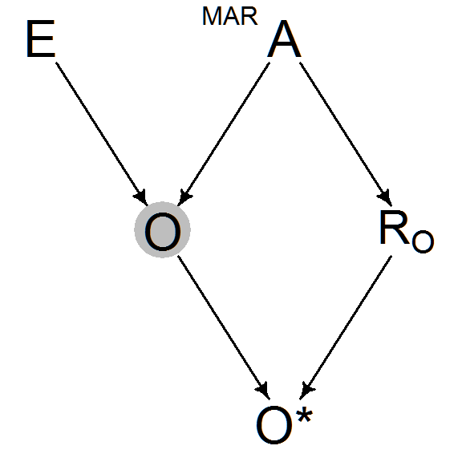

```r
drawdag(mar_dag)
mtext("MAR",side = 3,line = -1)
```

we can obtain an unbiased estimate by simply adjusting for A.

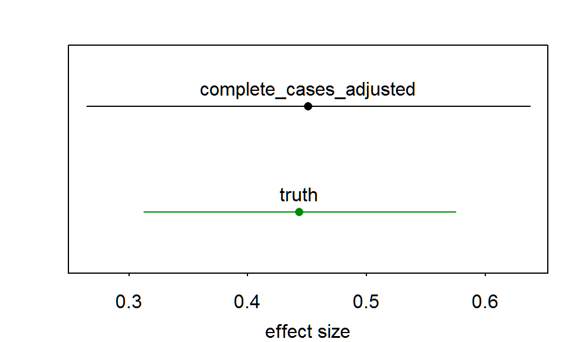

```r
my_data = sim_mDAG(mar_dag, N = 250)

lm_population = lm(O ~E, my_data)
lm_cc_adjusted = lm(`O*` ~ E + A, my_data)

es = rbind(truth =                   get_esci(lm_population)[2,],
           complete_cases_adjusted = get_esci(lm_cc_adjusted)[2,])

plot_coefs(es)
```

As expected, the standard error for the adjusted model based on complete data is larger (due to less data and more predictors).

### FIML regression in R with lavaan.

In the previous MAR scenario we could simply condition on A to remove bias. However, this is not possible if the predictor of missingness is also a mediator between the exposure and the outcome. The next figure shows an example:

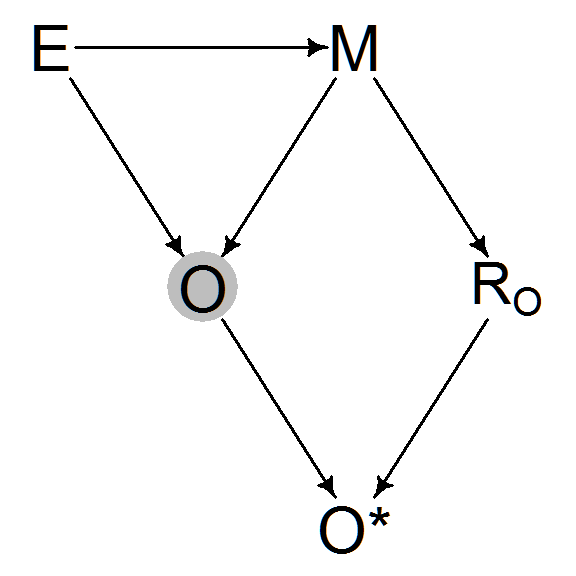

```r
mar_mediator_dag = dagitty("
M  1 @1,0
O  U @0,1
E  1 @-1,0
O* O @1,2
R_O 1 @2,1

M O R_O
E O M
O O*
R_O O*
")

mnarpred_dag = gsub("E -> M","E -> M [beta = 1]", mnarpred_dag)
mnarpred_dag = gsub("M -> R_O","M -> R_O [beta = 1]", mnarpred_dag)
drawdag(mar_mediator_dag)
```

Here, we can use the [lavaan](https://cran.rstudio.com/web/packages/lavaan/index.html) package which was (and is) developed to fit SEM model in R. However, it can also be used to fit *linear* FIML regression. Lets first look at the true association and association from futile methods to deal with missing data:

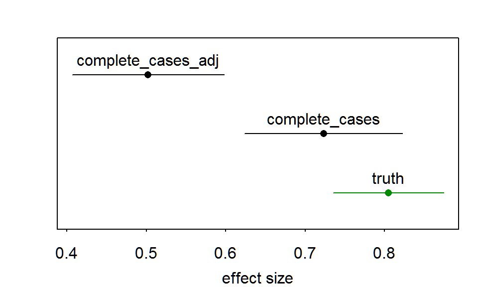

```r
my_data = sim_mDAG(mar_mediator_dag,
                   seed = 11)


es = rbind(truth =              get_esci(lm(O ~ E, my_data))[2,],
           complete_cases =     get_esci(lm(`O*` ~ E, my_data))[2,],
           complete_cases_adj = get_esci(lm(`O*` ~ E + M, my_data))[2,])

plot_coefs(es)
```

The correct total effect of E on O is 0.81. To recover this, we fit a FIML regression that models the effect of E and O and, importantly, the co-variances of M with O and E:

```r
library(lavaan)

model <- '
# regression model
Ox ~ E

# co-variances
Ox ~~ M
E ~~ M
'

my_data$Ox = my_data$`O*`
FIML_fit <- sem(model, my_data,
           missing='fiml',
           meanstructure=TRUE,
           fixed.x=FALSE)
summary(FIML_fit)
```

```
## lavaan 0.6-3 ended normally after 20 iterations
##
##   Optimization method                           NLMINB
##   Number of free parameters                          9
##
##   Number of observations                          1000
##   Number of missing patterns                         2
##
##   Estimator                                         ML
##   Model Fit Test Statistic                       0.000
##   Degrees of freedom                                 0
##
## Parameter Estimates:
##
##   Information                                 Observed
##   Observed information based on                Hessian
##   Standard Errors                             Standard
##
## Regressions:
##                    Estimate  Std.Err  z-value  P(>|z|)
##   Ox ~
##     E                 0.762    0.048   15.883    0.000
##
## Covariances:
##                    Estimate  Std.Err  z-value  P(>|z|)
##  .Ox ~~
##     M                 0.534    0.052   10.344    0.000
##   E ~~
##     M                 0.474    0.038   12.565    0.000
##
## Intercepts:
##                    Estimate  Std.Err  z-value  P(>|z|)
##    .Ox                0.047    0.049    0.961    0.336
##     E                -0.020    0.031   -0.644    0.520
##     M                -0.047    0.036   -1.319    0.187
##
## Variances:
##                    Estimate  Std.Err  z-value  P(>|z|)
##    .Ox                1.170    0.075   15.654    0.000
##     E                 0.940    0.042   22.361    0.000
##     M                 1.273    0.057   22.361    0.000
```

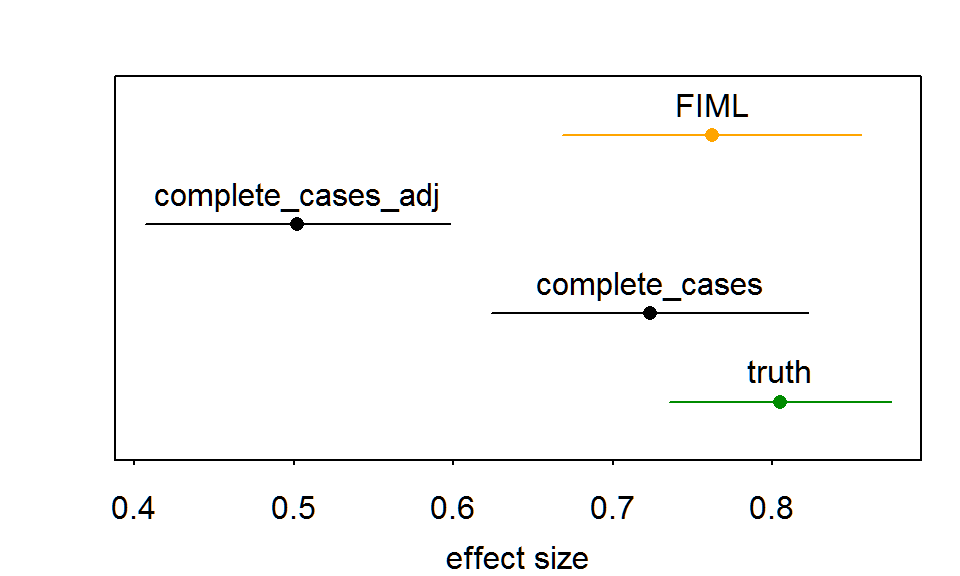

```r
es_FIML = parameterEstimates(FIML_fit)[1,c("est","ci.lower","ci.upper")]
colnames(es) = names(es_FIML)
es = rbind(es, es_FIML)
rownames(es)[4] = "FIML"

plot_coefs(es,
           clrs = c("green4","black","black","orange"))
```

Even if the FIML is not perfect, it is better than the complete case analysis. [^5]

### Multiple Imputation by Chained Equations with the mice package

An alternative to the FIML approach is to use multiple imputation by chained equation. The most popular R package for this is [mice](https://cran.rstudio.com/web/packages/mice/index.html). Some people have [strong opinions about FIML vs multiple imputations](https://statisticalhorizons.com/ml-better-than-mi). A fair summary seems to be that * FIML is preferred when missingness does not depend on auxiliary variables, the association between the involved variables is well described by a multivariate normal distribution, and there are no strong non-linearities (in the associations between variables) * MI is preferred when the imputation model has many variables not needed in the effect model, variables are not continuous, and interaction effects are important

One good reason to use `mice` as opposed to other R package for multiple imputation is the extensive documentation. Among other things there is an online [book](https://stefvanbuuren.name/fimd/) with lots of useful explanations and example code also for more advanced analyses, and a set of [vignettes](https://www.gerkovink.com/miceVignettes/) that serve as a moderately long introduction.

As a simple introduction to an analysis with mice, we analyse the MAR data that we just analysed with FIML. We start by generating multiple imputations of our data set:

```r
library(mice)

my_imputed_data = mice(
  my_data[,c("Ox","E","M")], # data with missing values
  m = 3,                     # number of imputed data sets
  maxit=25,                  # number of iterations in a chain
  meth='pmm',                # imputation method
  seed=500,
  printFlag = F)
```

Before we use the data, we should check if the imputation worked. One way to do this is to show densities and scatter plots with observed and imputed data in different colors.

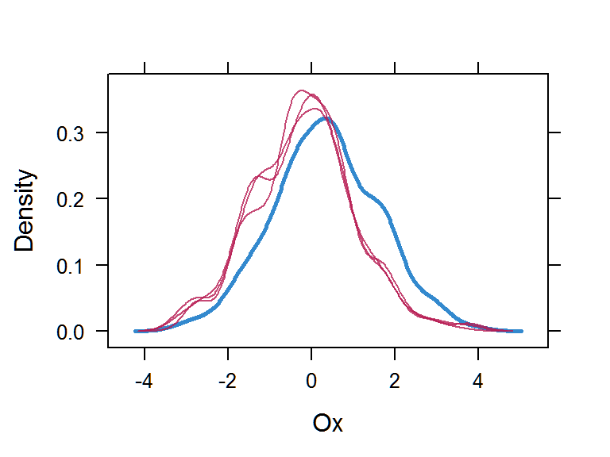

```r
par(mfrow = c(2,2))
densityplot(my_imputed_data)
```

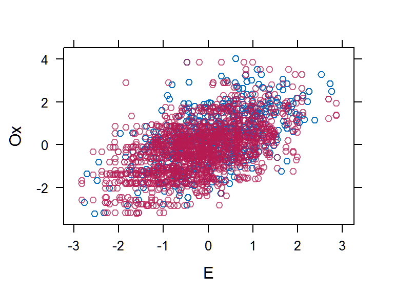

```r
xyplot(my_imputed_data,Ox ~ E)
```

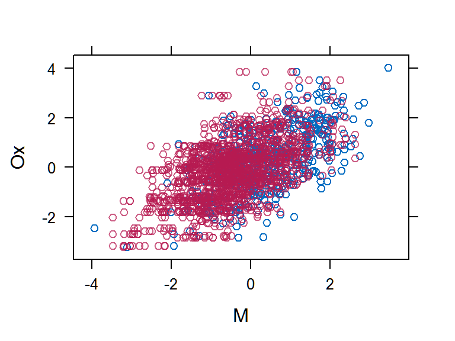

```r
xyplot(my_imputed_data,Ox ~ M)
```

Note that the lower mean for the imputed data is expected, because our data generating model specified that cases with low exposure values were more likely to have missing data for the outcome variable.

Three imputations were OK for visualization purposes, but we need more for the real analysis.

```r
my_imputed_data = mice(
  my_data[,c("Ox","E","M")], # data with missing values
  m = 100,                   # number of imputed data sets
  maxit=50,                  # number of iterations in a chain
  seed=500,
  printFlag = F)
```

Now we can also better visualize what the *multiple* means in multiple imputation. one missing value receives in each imputed data set a different value:

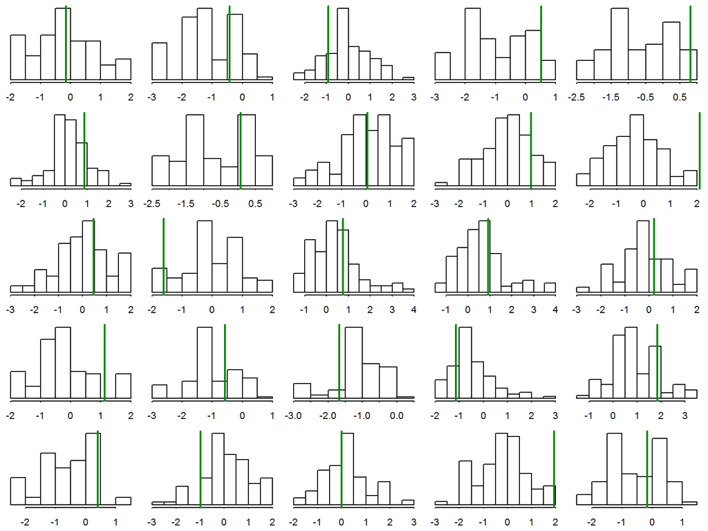

```r
idx_missing = which(!my_data$R_O)
par(mfrow = c(5,5), mar = c(2,.5,.5,.5),mgp=c(2,.7,0), tck=-.01)
for (k in 1:25) {
  hist(t(my_imputed_data$imp$Ox[k,]),
       xlab = "",
       ylab = "",
       bty = "n",
       yaxt = "n",
       main = "")
  abline(v = my_data$O[idx_missing[k]], col = "green4", lwd = 2)
}
```

Lets quickly check if the imputation indeed recovered correct values.

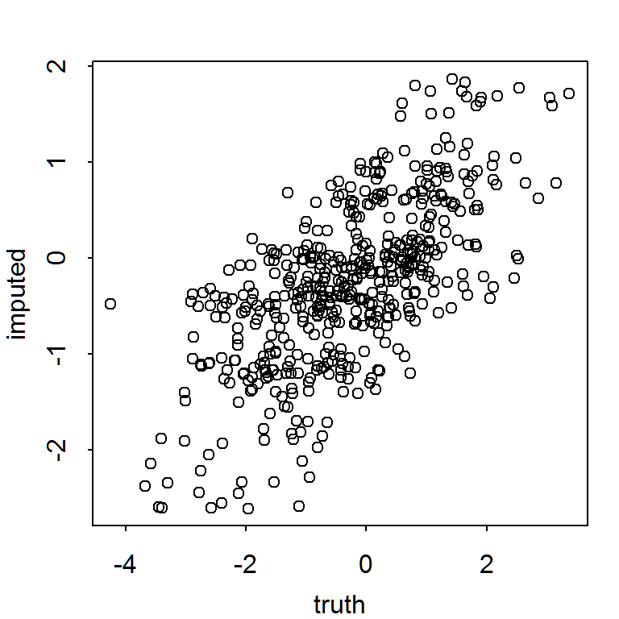

```r
par(mfrow = c(1,1),mar=c(3,3,2,1), mgp=c(2,.7,0), tck=-.01)
plot(my_data$O[idx_missing],
     rowMeans(my_imputed_data$imp$Ox),
     xlab = "truth",
     ylab = "imputed")
```

It did (Unfortunately we can’t do this for data from a real study. But we can do simulations to check if imputation is possible given an assumed DAG and percentage of missing data)

Now that we have checked the results of the imputation, we run the analysis with all imputed data sets:

```r
MI_fit = with(my_imputed_data,
              lm(Ox ~ E))
```

The object MI_fit is of the class [mira](https://stefvanbuuren.name/mice/reference/mira-class.html), and contains in slot four (`MI_fit[4]` or `MI_fit$analyses` or `MI_fit[analyses]`) for each imputed data set the result of the regression model we specified. We can look at all coefficients:

```r
summary(MI_fit)
```

```
## # A tibble: 200 x 5
##    term        estimate std.error statistic  p.value
##    <chr>          <dbl>     <dbl>     <dbl>    <dbl>
##  1 (Intercept)   0.0222    0.0342     0.650 5.16e- 1
##  2 E             0.738     0.0352    20.9   5.02e-81
##  3 (Intercept)  -0.0170    0.0339    -0.500 6.17e- 1
##  4 E             0.742     0.0350    21.2   8.63e-83
##  5 (Intercept)   0.0845    0.0337     2.51  1.22e- 2
##  6 E             0.756     0.0347    21.8   2.35e-86
##  7 (Intercept)   0.0323    0.0342     0.944 3.46e- 1
##  8 E             0.778     0.0353    22.1   3.12e-88
##  9 (Intercept)   0.0415    0.0333     1.25  2.13e- 1
## 10 E             0.754     0.0343    21.9   2.30e-87
## # ... with 190 more rows
```

And we can look at the pooled the results:

```r
s = summary(pool(MI_fit), conf.int = T)
s[,1:5]
```

```
##               estimate  std.error  statistic       df   p.value
## (Intercept) 0.04674223 0.04871834  0.9594381 208.3043 0.3380541
## E           0.75483330 0.04431153 17.0346942 323.7208 0.0000000
```

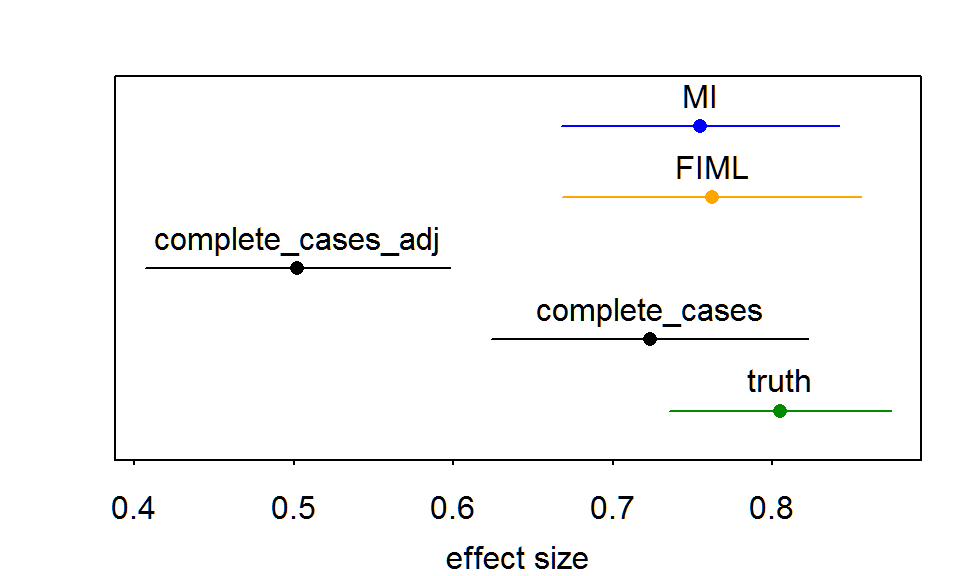

```r
es_MI = s[2,c("estimate","2.5 %","97.5 %")]
names(es_MI) = names(es)
es = rbind(es, es_MI)
rownames(es)[5] = "MI"

plot_coefs(es,
           clrs = c("green4","black","black","orange","blue"))
```

### Missing data and non-linear effects

In the previous example, MI and FIML lead more or less to the same results, because the involved variables are in fact multivariate normal and no interaction effects were present. In the final example we shall investigate such and example. The following situation is the same as above, except that we have an additional variable L for county (fylke). The idea is that the outcome obesity and participation could depend on where one lives.

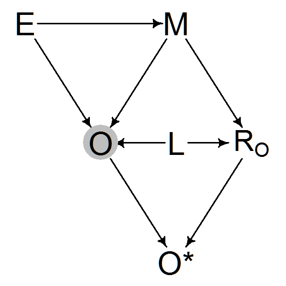

```r
mar_interaction_dag = dagitty("
M  1 @1,0
O  U @0,1
E  1 @-1,0
O* O @1,2
R_O 1 @2,1
L 1 @1,1

M O R_O
E O M
O O*
R_O O*
L O R_O
")
drawdag(mar_interaction_dag)
```

In all previous analyses we could use `dagitty`’s `simulateSEM` function to generate data from a DAG, because we treated data as multivariate normal. However, we can’t do this now, because

- L is a categorical variables and
- the effect of L on O is assumed to be that of an effect modifier.

The following code generates data from this model:

```r
N = 500
# we start with the exogeneous variables:
E = rnorm(N)
# now the endogenous variables
M = E + rnorm(N)
# cases come from 5 counties
L = cut(runif(N),
        breaks = seq(-.001,1.001,length = 6),
        labels = paste0("L",1:5),
        ordered_result = T)
# O depends on M and E, whereby the effect of E depends on L
O = M - E * scale(as.numeric(L))*2 + rnorm(N)
# R_O depends on M plus a non-linear effect of C
R_O = M + poly(as.numeric(L),2) %*% c(20,20) + rnorm(N)
R_O = R_O > 0
# now we can define the observed data
`O*` = O
`O*`[!R_O] = NA
Ox = `O*`

mar_interaction_data = data.frame(E = E, M = M,
                                  O = O, L = L, R_O = R_O,
                                  `O*` = `O*`, Ox = Ox)
```

Now we can look at the association between E and O, stratified by participation.

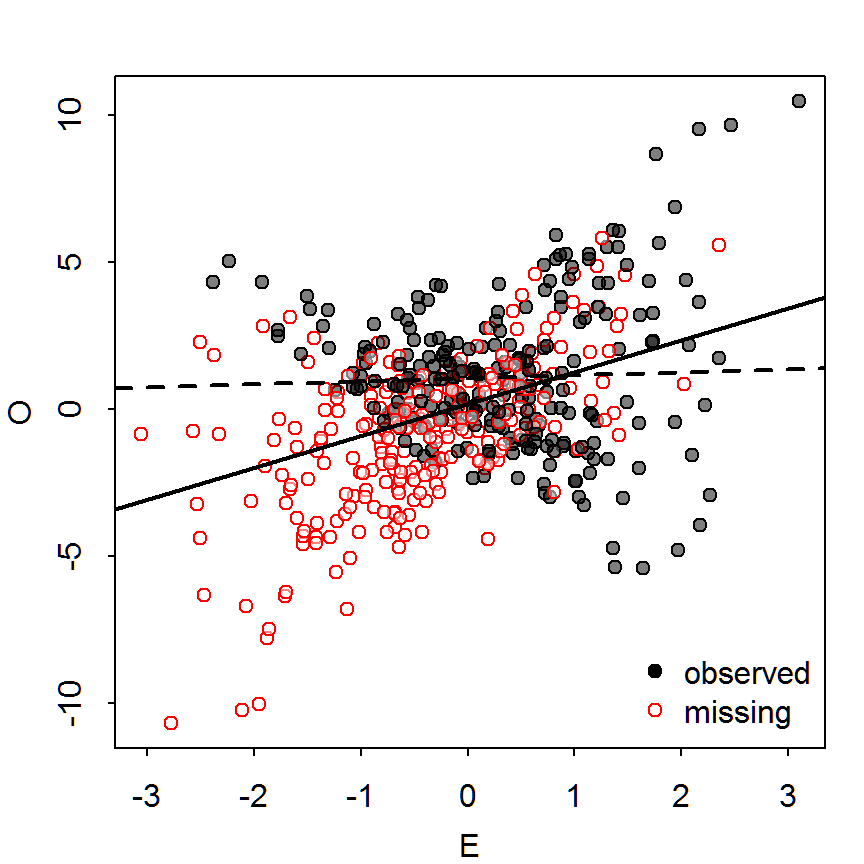

```r
par (mar=c(3,3,2,1), mgp=c(2,.7,0), tck=-.01)
bg = sapply(R_O,
            function(x)
              ifelse(x == T,
                     "black",
                     "white"))
plot(E,O, pch = 21, bg=adjustcolor(bg,alpha = .5), col = (!R_O)+1)
abline(lm(O~E), col = "black", lwd = 2)
abline(lm(`O*`[R_O]~E[R_O]), col = "black", lwd = 2, lty = 2)
legend("bottomright",
       pch = c(21,21),
       col = c("black","red"),
       pt.bg = c(1,0),
       legend = c("observed","missing"),
       bty = "n")
```

Obviously, we would get a biased estimate when using only complete cases. We also can’t adjust for M, because M is a mediator. So lets try FIML:

```r
mar_interaction_data$Ln = scale(as.numeric(mar_interaction_data$L))
model <- '
# regression model
Ox ~ E

# co-variances
Ox ~~ M
E ~~ M
Ox ~~ Ln
E ~~ Ln
M ~~ Ln
'

FIMLi_fit <- sem(model,
                mar_interaction_data,
                missing='fiml',
                meanstructure=TRUE,
                fixed.x=FALSE)
summary(FIML_fit)
```

[output not shown]

Note that here we transformed the ordinal variable L to a numeric variable, because `lavaan` cannot deal with categorical variables when doing FIML estimation (Mplus can). Still, the results are off, because we haven’t added information about the interaction to the model. The next model does this.

```r
mar_interaction_data$iEL = scale(as.numeric(mar_interaction_data$L)) * E
mar_interaction_data$nL = scale(as.numeric(mar_interaction_data$L))

model <- '
# regression model
Ox ~ E

# co-variances
Ox ~~ M
Ox ~~ iEL
E ~~ M
nL ~~ M
nL ~~ Ox
nL ~~ iEL
'

FIMLi_fit <- sem(model,
                mar_interaction_data,
                missing='fiml',
                meanstructure=TRUE,
                fixed.x=FALSE)
summary(FIMLi_fit)
```

```
## lavaan 0.6-3 ended normally after 42 iterations
##
##   Optimization method                           NLMINB
##   Number of free parameters                         17
##
##   Number of observations                           500
##   Number of missing patterns                         2
##
##   Estimator                                         ML
##   Model Fit Test Statistic                       0.607
##   Degrees of freedom                                 3
##   P-value (Chi-square)                           0.895
##
## Parameter Estimates:
##
##   Information                                 Observed
##   Observed information based on                Hessian
##   Standard Errors                             Standard
##
## Regressions:
##                    Estimate  Std.Err  z-value  P(>|z|)
##   Ox ~
##     E                 0.987    0.090   11.014    0.000
##
## Covariances:
##                    Estimate  Std.Err  z-value  P(>|z|)
##  .Ox ~~
##     M                 1.032    0.101   10.187    0.000
##     iEL              -1.960    0.140  -13.974    0.000
##   E ~~
##     M                 0.995    0.079   12.548    0.000
##   nL ~~
##     M                -0.001    0.048   -0.011    0.991
##  .Ox ~~
##     nL               -0.026    0.121   -0.214    0.831
##   nL ~~
##     iEL              -0.037    0.044   -0.830    0.406
##
## Intercepts:
##                    Estimate  Std.Err  z-value  P(>|z|)
##    .Ox                0.249    0.132    1.883    0.060
##     E                -0.058    0.045   -1.304    0.192
##     nL               -0.000    0.045   -0.000    1.000
##     M                -0.002    0.065   -0.032    0.975
##     iEL              -0.032    0.044   -0.734    0.463
##
## Variances:
##                    Estimate  Std.Err  z-value  P(>|z|)
##    .Ox                5.841    0.411   14.212    0.000
##     E                 1.005    0.064   15.811    0.000
##     nL                0.998    0.063   15.811    0.000
##     M                 2.141    0.135   15.807    0.000
##     iEL               0.969    0.061   15.811    0.000
```

Indeed, the result looks nice. This drives again home that it is important to have a good idea about the data generating process when one deals with missing data.

Now let’s try multiple imputation by chained equations (MICE). We start with getting a quick overview about the missing data pattern.

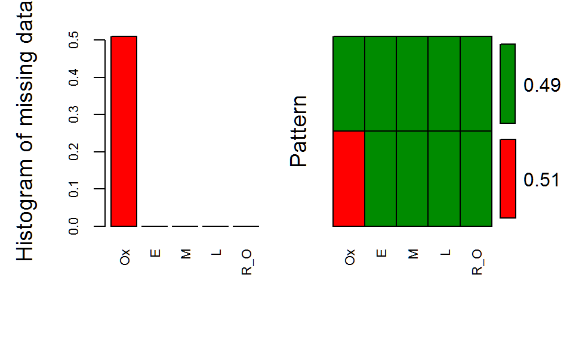

```
##
##  Variables sorted by number of missings:
##  Variable Count
##        Ox  0.51
##         E  0.00
##         M  0.00
##         L  0.00
##       R_O  0.00
```

```r
library(VIM)
idata = mar_interaction_data[,c("E","M","L","Ox","R_O")]
#for (v in 1:3)
#  idata[sample(N,N*.1),v] = NA

aggr_plot = aggr(idata,
                 col=c('green4','red'),
                 numbers=TRUE,
                 sortVars=TRUE,
                 labels=names(data),
                 cex.axis=.7,
                 gap=3,
                 ylab=c("Histogram of missing data",
                        "Pattern"))
```

The basic command to impute data is simple:

```r
my_imputed_data2 = mice(
  idata,              # data with missing values
  m = 3,              # number of imputed data sets
  maxit=25,           # number of iterations in a chain
  seed=500,
  printFlag = F)
```

Before we look at the results, lets check the imputation model, i.e. how mice did the imputations.

```r
my_imputed_data2$method
```

```
##     E     M     L    Ox   R_O
##    ""    ""    "" "pmm"    ""
```

```r
my_imputed_data2$predictorMatrix
```

```
##     E M L Ox R_O
## E   0 1 1  1   1
## M   1 0 1  1   1
## L   1 1 0  1   1
## Ox  1 1 1  0   1
## R_O 1 1 1  1   0
```

```r
my_imputed_data2$formulas
```

```
## $E
## E ~ 0 + M + L + Ox + R_O
## <environment: 0x000000003dc37788>
##
## $M
## M ~ 0 + E + L + Ox + R_O
## <environment: 0x000000003dc37788>
##
## $L
## L ~ 0 + E + M + Ox + R_O
## <environment: 0x000000003dc37788>
##
## $Ox
## Ox ~ 0 + E + M + L + R_O
## <environment: 0x000000003dc37788>
##
## $R_O
## R_O ~ 0 + E + M + L + Ox
## <environment: 0x000000003dc37788>
```

The first line shows us the imputation method (here [pmm](https://stefvanbuuren.name/fimd/sec-pmm.html), predictive mean matching see also [here](https://statisticalhorizons.com/predictive-mean-matching))

Lets see if the results look reasonable by looking at density and scatter plots.

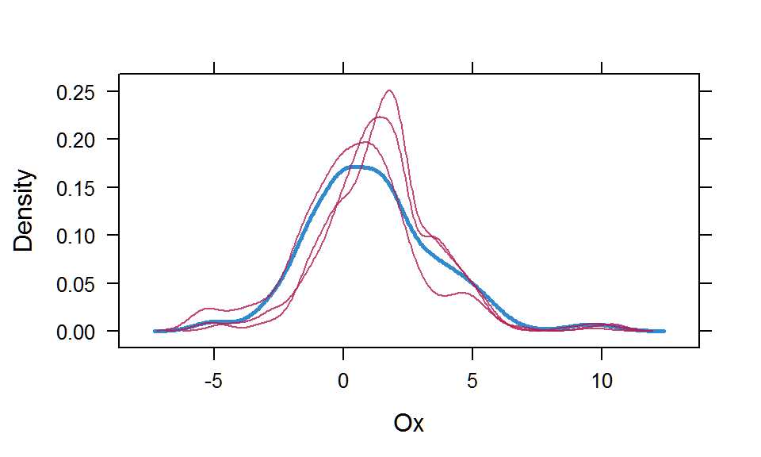

```r
densityplot(my_imputed_data2)
```

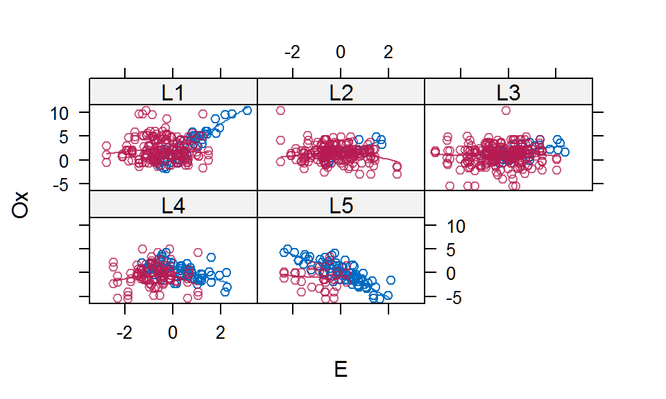

```r
xyplot(my_imputed_data2,
       Ox ~ E | L,
       type = c("p", "smooth"))
```

Definitively not great, rather horrible. The one reason is that model does not take into account interaction terms. `mice` uses the concept of *passive imputation* to insure that derived variables (like interactions) are consistent with imputations throughout the imputation process. Detailed information about specifying such more complex imputation models can be found [here](https://stefvanbuuren.name/fimd/sec-knowledge.html), including a section about [efficient imputations of sum-scores](https://stefvanbuuren.name/fimd/sec-knowledge.html#sec:sumscores). To set up passive imputation of an interaction variable one has to:

- initialize hat variable
- specify a method for that variable, i.e. define an R expression that tells mice how to generate the derived variable
- adjust the prediction matrix to make sure the derived variable is only used as a predictor where needed

In addition we also add a variable that codes if Ox was missing as a predictor (a trick from the [mi package](https://cran.rstudio.com/web/packages/mi/)).

```r
idata$iEL = as.vector(idata$E * scale(as.numeric(idata$L)))
method = make.method(idata)

expr = expression(scale(as.numeric(L)) * E)
method["iEL"] = paste("~I(", expr, ")", sep = "")
method["R_O"] = "logreg"

pred = make.predictorMatrix(idata)
pred[c("E","L","M","Ox"),"iEL"] = 0
pred["Ox","iEL"] = 1
pred["Ox",c("E","L")] = 0
pred
```

```
##     E M L Ox R_O iEL
## E   0 1 1  1   1   0
## M   1 0 1  1   1   0
## L   1 1 0  1   1   0
## Ox  0 1 0  0   1   1
## R_O 1 1 1  1   0   1
## iEL 1 1 1  1   1   0
```

```r
imp <- mice(idata,
            meth = method,    # method for passive imputation
            pred = pred,      # matrix of predictors for all variables
            m = 3,            # number of imputed data sets
            maxit=250,         # number of iterations in a chain
            seed=500,
            printFlag = F)
```

Now that we have a model that is a bit more complex we go through more “checking” steps. MICE is a Monta Carlo algorithm, so we need to check convergence. We do this by plotting how parameters change over time (there are more sophisticated ways to do this, like comparing within and between chain variance, but MICE does not support those.)

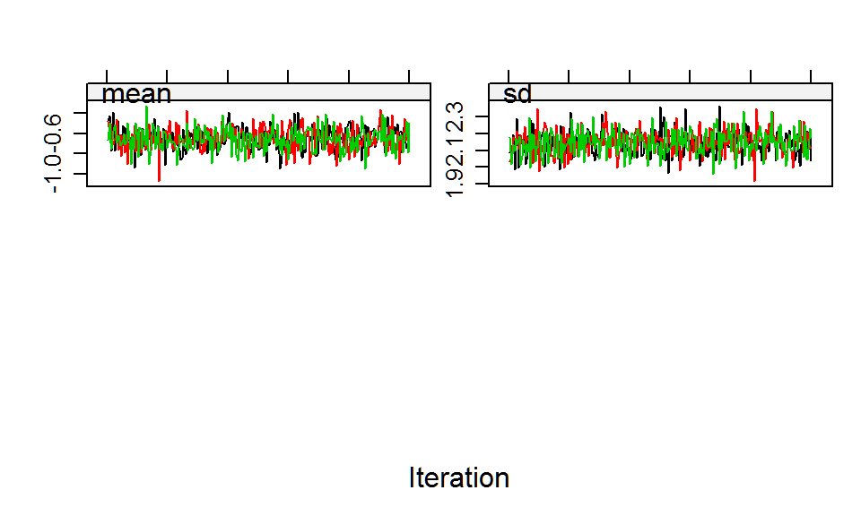

```r
plot(imp)
```

And we use strip plots to check if all variables have plausible values (i.e. they are not outside the range of the observed values)

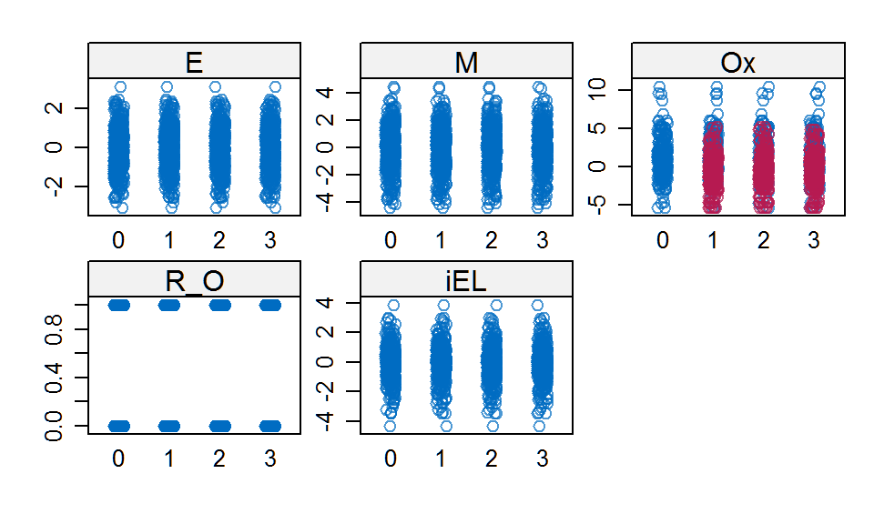

```r
stripplot(imp)
```

Density plots do a similar job.

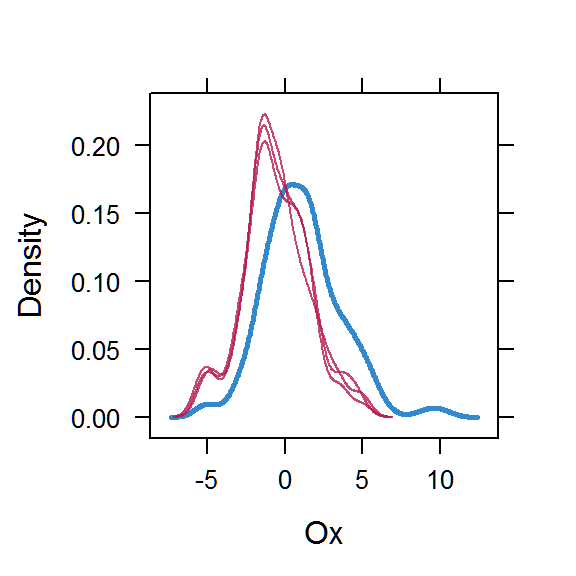

```r
densityplot(imp)
```

Particularly interesting are the associations between O/Ox and E given L. We first look at the complete data and then at the imputed data.

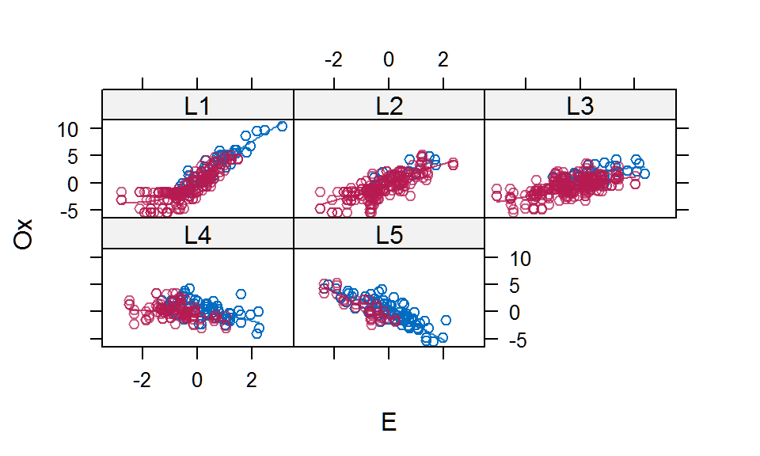

```r
xyplot(imp,
       Ox ~ E | L,
       type = c("p", "smooth"))
```

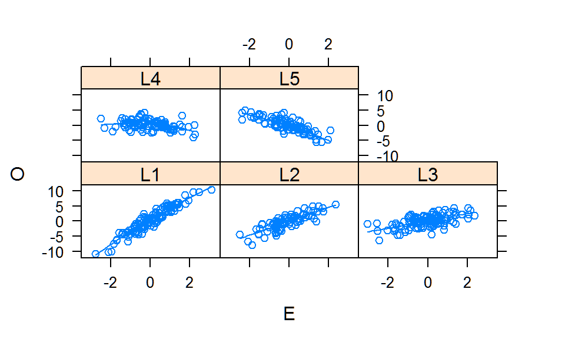

```r
xyplot(O ~ E | L,
       mar_interaction_data,
       type = c("p", "smooth"),
       index.cond=list(c(1:5)))
```

While the imputation was not perfect (there is a problem with L1) we see that we have filled in lots of cases for groups L1-L3, where the correlation is typically positive. A complete case analysis without these imputed data points naturally underestimates the association between E and O. Still, before we move on, lets see if we can improve the imputation by using a different imputation method than predictive mean matching (pmm) for Ox.

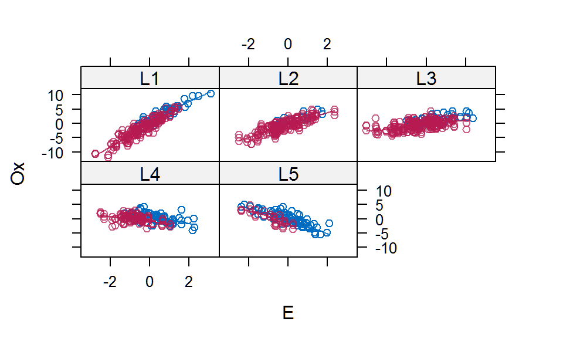

```r
method["Ox"] = "norm"
imp <- mice(idata,
            meth = method,    # method for passive imputation
            pred = pred,      # matrix of predictors for all variables
            m = 3,            # number of imputed data sets
            maxit=250,         # number of iterations in a chain
            seed=500,
            printFlag = F)
xyplot(imp,
       Ox ~ E | L,
       type = c("p", "smooth"))
```

OK, this looks much better. *The problem with predictive mean matching is, that it will not allow more extreme values than the observed ones. However, for the data generating process we are looking at, the most extreme values were missing. If this is a possibility, which will often be the case when missingness depends on (unobserved) outcome variables, pmm is not a good imputation method.*

Now we re-do the imputation to generate more data sets and then run the analysis.

```r
imp <- mice(idata,
            meth = method,    # method for passive imputation
            pred = pred,      # matrix of predictors for all variables
            m = 100,           # number of imputed data sets
            maxit=50,         # number of iterations in a chain
            seed=500,
            printFlag = F)

MI_fit2 = with(imp,
              lm(Ox ~ E))
summary(pool(MI_fit2), conf.int = T)
```

```
##              estimate std.error statistic       df      p.value
## (Intercept) 0.1744543 0.1277855  1.365212 306.3769 1.731014e-01
## E           1.0237712 0.1243664  8.231895 335.3808 3.996803e-15
##                   2.5 %    97.5 %
## (Intercept) -0.07699392 0.4259026
## E            0.77913472 1.2684078
```

And we compare the results of different models:

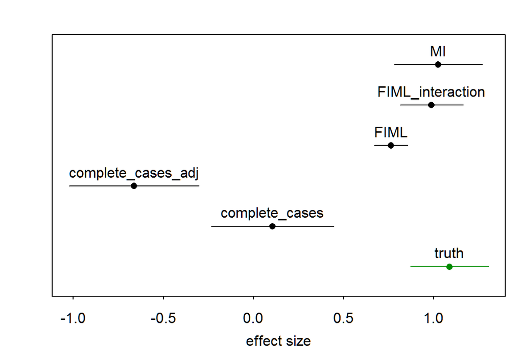

```r
esMI_fits = summary(pool(MI_fit2),
                        conf.int = T)[2,c("estimate","2.5 %","97.5 %")]
es_FIML = parameterEstimates(FIML_fit)[1,c("est","ci.lower","ci.upper")]
colnames(es_FIML) = colnames(esMI_fits)
es_FIMLi = parameterEstimates(FIMLi_fit)[1,c("est","ci.lower","ci.upper")]
colnames(es_FIMLi) = colnames(esMI_fits)



es = rbind(
  truth =
    get_esci(lm(O ~ E, mar_interaction_data))[2,],
  complete_cases =
    get_esci(lm(`O*` ~ E, mar_interaction_data))[2,],
  complete_cases_adj =
    get_esci(lm(`O*` ~ E + M + L, mar_interaction_data))[2,],
  FIML           =
    es_FIML,
  FIML_interaction =
    es_FIMLi,
  MI             =
    esMI_fits
  )

plot_coefs(es)
```

So FIML and MI both generate useful results, as long as one is careful in specifying a correct model. This reinforces that careful exploration of the data and considerate use of an imputation model are crucial for successful imputation.

In the current example both FIML and MI allow us to handle missing data properly. Still, MI is generally more flexible because

- it is easier to define complex missing data models
- imputed data can be fed into any follow up analysis, some of which might not be available with `lavaan`.

## Summary

- R typically returns `NA` when an operation is performed with missing data. The important exception is regression models, where complete case analysis is the default
- When modeling exposure outcome associations, missing data are most problematic if *outcome* data is MNAR
- Complete case analysis under missingness of predictor variables results in larger than necessary standard errors (but the effect size will not be biased)
- it is important to explicitly specify (and check) a missing data model
- valid ways to deal with missing data include
  - adjustment for missingness predictors (depends on missing data model and will still have larger than necessary standard errors)
  - Full information maximum likelihood (FIML) as for example in the `lavaan` package. FIML does not “just work” and also requires a thinking about the missing data model
  - Multiple imputation (MI) as for example in the `mice` package. This is the most flexible approach

## Resources

- A general introduction on [how R handles missing data](https://stats.idre.ucla.edu/r/faq/how-does-r-handle-missing-values/)
- R [task view](https://cran.r-project.org/web/views/MissingData.html) about missing data
- Stef van Buren’s (author of `mice`) book
- [Vignettes](https://www.gerkovink.com/miceVignettes/) for using `mice`
- Bayesian [joint estimation of imputation and effect model](https://cran.r-project.org/web/packages/brms/vignettes/brms_missings.html) with brms
[^1]: There are exceptions, see Mohan & Pearl, 2018
[^2]: i.e. don’t say an effect of .05 +/- .02 is practically equivalent with zero when assessing conditional independence, and later call an exposure outcome association of .06 +/- .03 “significant”
[^3]: Note that using only complete cases would bias the error variance upwards. In contrast, mean imputation would bias error variance downwards
[^4]: I guess this is rarely the case
[^5]: With more time, one should add some simulations to show that the FIML approach is unbiased and the complete case approach not. Same for all other methods